# BFALgtseq-test2

11 January 2023

This is the second test of the primers for the BFAL.

Reminding myself: I used two separate primer pools, each with 48/96 samples.

## Taking a look at output from GTscore

```r
library(tidyverse)
```

The plot we want is the R1 reads where the FWD primer was found vs. the flashed read where the FWD primer was found.

```r
# read in the GTscore output

flashed <- read_tsv("../data/test2/flashed_locusSummary.txt") %>%
  select(Locus, `Primer Reads`) %>%
  rename(flashed_reads = `Primer Reads`)
R1 <- read_tsv("../data/test2/R1_unzipped_locusSummary.txt") %>%
  select(Locus, `Primer Reads`) %>%
  rename(R1_reads = `Primer Reads`)
```

Look at those two df combined based on locus

| Locus | R1_reads | flashed_reads |
| --- | --- | --- |
| BFAL_scaffold_0_4330405 | 0 | 0 |
| BFAL_scaffold_0_4543438 | 4751 | 4572 |
| BFAL_scaffold_1_5556176 | 777 | 745 |
| BFAL_scaffold_3_875260 | 2449 | 2289 |
| BFAL_scaffold_4_4005861 | 1174 | 1133 |
| BFAL_scaffold_5_3710486 | 2991 | 2386 |
| BFAL_scaffold_5_3862639 | 8734 | 4128 |
| BFAL_scaffold_5_523288 | 4373 | 1324 |
| BFAL_scaffold_5_697809 | 3960 | 3769 |
| BFAL_scaffold_7_15896 | 196 | 185 |

[output cut: 334 more lines]

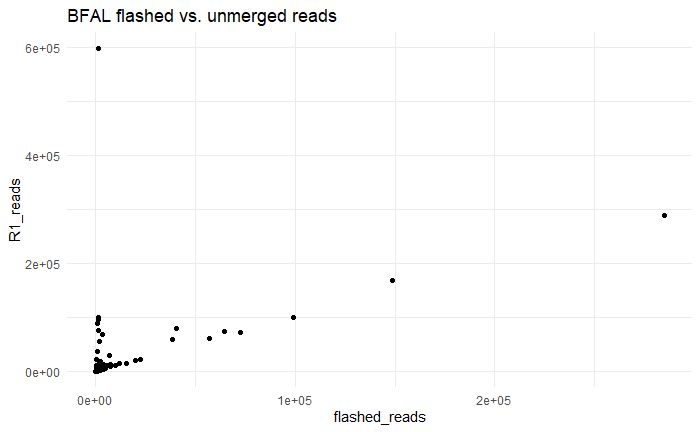

```r
combo_df %>%
  ggplot(aes(x = flashed_reads, y = R1_reads)) +
  geom_point() +
  labs(title = "BFAL flashed vs. unmerged reads") +
  theme_minimal()
```

```r
NA
NA
```

So the loci that would be concerning are those with high numbers for the unmerged (R1) reads and disproportionately low numbers for the flashed reads in comparison.

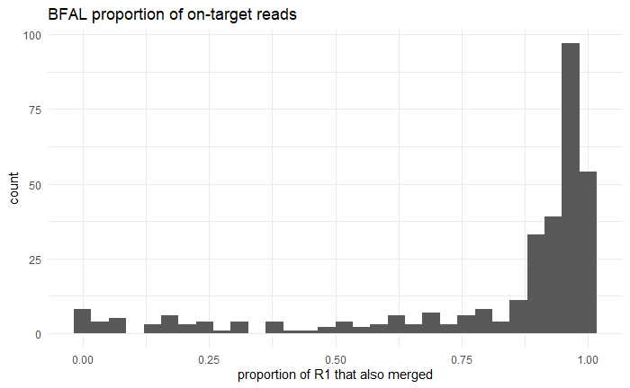

```r
# create a proportion difference
combo_df %>%
  mutate(prop = flashed_reads/R1_reads) %>%
  ggplot(aes(x = prop)) +
  geom_histogram() +
  labs(x = "proportion of R1 that also merged",
       title = "BFAL proportion of on-target reads") +
  theme_minimal()
```

```r
NA
NA
```

More generally, what’s the distribution of reads across loci?

| read_type | sum(reads) |
| --- | --- |
| flashed_reads | 1329026 |
| R1_reads | 2798712 |

```r
1329026/2798712
```

```
[1] 0.4748706
```

~50% total on-target makes sense given the dimer.

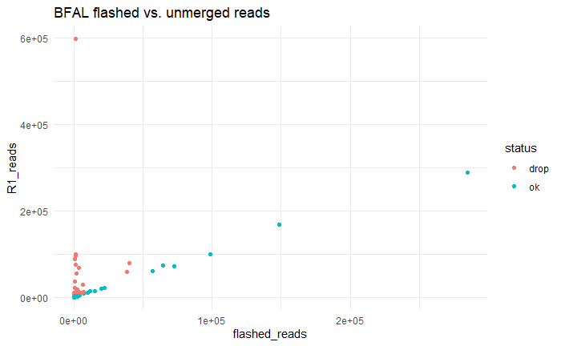

```r
combo_df %>%
  filter(!R1_reads == 0) %>% # these correspond to the 18 loci that I removed based on the first iteration.
  mutate(prop = flashed_reads/R1_reads) %>%
  #filter(prop < 0.75 & R1_reads > 10000) %>% # how many loci with < 75% on-target?
  mutate(status = ifelse(prop < 0.75 & R1_reads >5000, "drop", "ok")) %>%
  ggplot(aes(x = flashed_reads, y = R1_reads, color = status)) +
  geom_point() +
  labs(title = "BFAL flashed vs. unmerged reads") +
  theme_minimal()
```

Zoom in on the origin to see what’s going on.

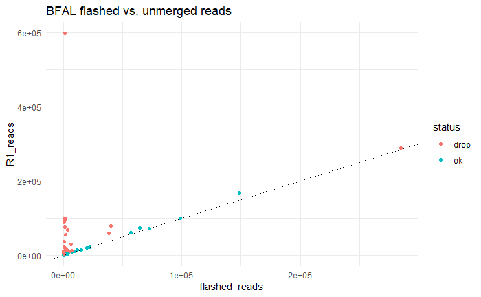

```r
combo_df %>%
  filter(!R1_reads == 0) %>% # these correspond to the 18 loci that I removed based on the first iteration.
  mutate(prop = flashed_reads/R1_reads) %>%
  #filter(prop < 0.75 & R1_reads > 10000) %>% # how many loci with < 75% on-target?
  mutate(status = ifelse(prop < 0.8 & R1_reads >3900 | flashed_reads > 200000, "drop", "ok")) %>%
  ggplot(aes(x = flashed_reads, y = R1_reads, color = status)) +
  geom_point() +
  geom_abline(linetype = "dotted") +
  labs(title = "BFAL flashed vs. unmerged reads") +
  theme_minimal()

ggsave("pdf_outputs/test2_merged_vs_R1.pdf")
```

Maybe that’s too stringent?

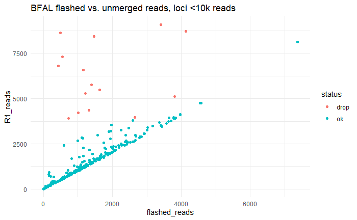

```r
combo_df %>%
  filter(!R1_reads == 0) %>% # these correspond to the 18 loci that I removed based on the first iteration.
  mutate(prop = flashed_reads/R1_reads) %>%
  mutate(status = ifelse(prop < 0.8 & R1_reads >3900, "drop", "ok")) %>%
  filter(flashed_reads < 10000 & R1_reads < 10000) %>%
  ggplot(aes(x = flashed_reads, y = R1_reads, color = status)) +
  geom_point() +
  labs(title = "BFAL flashed vs. unmerged reads, loci <10k reads") +
  theme_minimal()

ggsave("pdf_outputs/test2_merged_v_R1_under10k.pdf")
```

Now zoom in on loci with > 10k reads

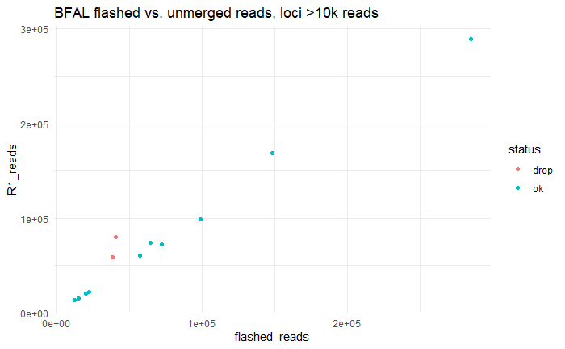

```r
combo_df %>%
  filter(!R1_reads == 0) %>% # these correspond to the 18 loci that I removed based on the first iteration.
  mutate(prop = flashed_reads/R1_reads) %>%
  #filter(prop < 0.75 & R1_reads > 10000) %>% # how many loci with < 75% on-target?
  mutate(status = ifelse(prop < 0.75 & R1_reads >3900, "drop", "ok")) %>%
  filter(flashed_reads > 10000 & R1_reads > 10000) %>%
  ggplot(aes(x = flashed_reads, y = R1_reads, color = status)) +
  geom_point() +
  labs(title = "BFAL flashed vs. unmerged reads, loci >10k reads") +
  theme_minimal()
```

The final thing I’m curious about is whether the off-target loci that were retained from the first iteration just received too few reads the first time around to adequately assess them?

Which loci am I planning on removing based on gtseq test 2?

```r
combo_df %>%
  filter(!R1_reads == 0) %>% # these correspond to the 18 loci that I removed based on the first iteration.
  mutate(prop = flashed_reads/R1_reads) %>%
  #filter(prop < 0.75 & R1_reads > 10000) %>% # how many loci with < 75% on-target?
  mutate(status = ifelse(prop < 0.9 & R1_reads >3900 | flashed_reads > 200000, "drop", "ok")) %>%
  filter(status == "drop")
```

| Locus | R1_reads | flashed_reads | prop | status |
| --- | --- | --- | --- | --- |
| BFAL_scaffold_5_3862639 | 8734 | 4128 | 0.472635677 | drop |
| BFAL_scaffold_5_523288 | 4373 | 1324 | 0.302766979 | drop |
| BFAL_scaffold_10_1427435 | 10799 | 3195 | 0.295860728 | drop |
| BFAL_scaffold_10_2628257 | 15905 | 1986 | 0.124866394 | drop |
| BFAL_scaffold_10_3913065 | 17866 | 2526 | 0.141385873 | drop |
| BFAL_scaffold_14_2620367 | 6587 | 1151 | 0.174738121 | drop |
| BFAL_scaffold_15_1957403 | 12177 | 2446 | 0.200870494 | drop |
| BFAL_scaffold_19_1937583 | 169248 | 148515 | 0.877499291 | drop |
| BFAL_scaffold_21_3344501 | 5475 | 1635 | 0.298630137 | drop |
| BFAL_scaffold_27_47556 | 10272 | 6421 | 0.625097352 | drop |

[output cut: 32 more lines]

```r
NA
```

| Locus | R1_reads | flashed_reads | prop | status |
| --- | --- | --- | --- | --- |
| BFAL_scaffold_0_4543438 | 4751 | 4572 | 0.96232372 | ok |
| BFAL_scaffold_1_5556176 | 777 | 745 | 0.95881596 | ok |
| BFAL_scaffold_3_875260 | 2449 | 2289 | 0.93466721 | ok |
| BFAL_scaffold_4_4005861 | 1174 | 1133 | 0.96507666 | ok |
| BFAL_scaffold_5_3710486 | 2991 | 2386 | 0.79772651 | ok |
| BFAL_scaffold_5_697809 | 3960 | 3769 | 0.95176768 | ok |
| BFAL_scaffold_7_15896 | 196 | 185 | 0.94387755 | ok |
| BFAL_scaffold_7_3089859 | 1954 | 1892 | 0.96827021 | ok |
| BFAL_scaffold_7_4109482 | 3931 | 3832 | 0.97481557 | ok |
| BFAL_scaffold_8_2680159 | 2910 | 2840 | 0.97594502 | ok |

[output cut: 274 more lines]

That leaves a total of 284 remaining.

Quick look at the 42 I’m thinking of dropping from round 1.

```r
# read in the GTscore output

test1_flashed <- read_tsv("../data/flashed_GTscore_locusSummary.txt") %>%
  select(Locus, `Primer Reads`) %>%
  rename(flashed_reads = `Primer Reads`)
test1_R1 <- read_tsv("../data/R1_GTscore_locusSummary.txt") %>%
  select(Locus, `Primer Reads`) %>%
  rename(R1_reads = `Primer Reads`)
```

| Locus | R1_reads.x | flashed_reads.x | prop.x | status | R1_reads.y | flashed_reads.y | prop.y |
| --- | --- | --- | --- | --- | --- | --- | --- |
| BFAL_scaffold_10_1427435 | 10799 | 3195 | 0.2958607 | drop | 547 | 312 | 0.5703839 |
| BFAL_scaffold_15_1957403 | 12177 | 2446 | 0.2008705 | drop | 294 | 176 | 0.5986395 |
| BFAL_scaffold_19_1937583 | 169248 | 148515 | 0.8774993 | drop | 5882 | 4914 | 0.8354301 |
| BFAL_scaffold_27_47556 | 10272 | 6421 | 0.6250974 | drop | 788 | 425 | 0.5393401 |
| BFAL_scaffold_44_1119351 | 5111 | 3809 | 0.7452553 | drop | 218 | 192 | 0.8807339 |
| BFAL_scaffold_48_950302 | 11538 | 5781 | 0.5010400 | drop | 574 | 446 | 0.7770035 |
| BFAL_scaffold_75_1108391 | 13751 | 12029 | 0.8747727 | drop | 1185 | 931 | 0.7856540 |
| BFAL_scaffold_111_413509 | 3960 | 2650 | 0.6691919 | drop | 46 | 44 | 0.9565217 |
| BFAL_scaffold_152_234875 | 11862 | 7169 | 0.6043669 | drop | 243 | 146 | 0.6008230 |
| BFAL_scaffold_200_222308 | 80127 | 40362 | 0.5037253 | drop | 4657 | 2614 | 0.5613056 |

[output cut: 3 more lines]

Take a look at just a couple of them:

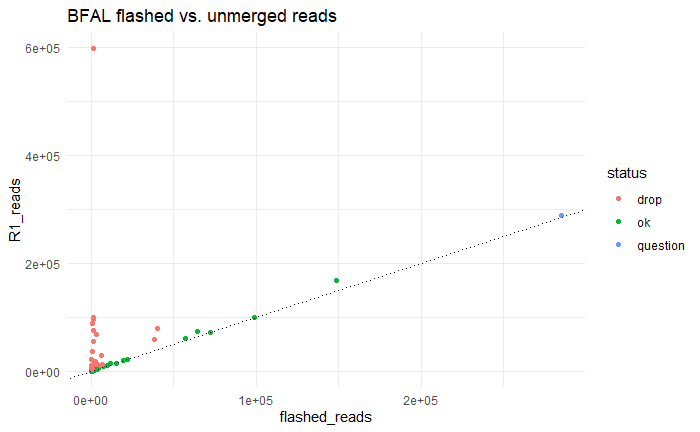

```r
combo_df %>%
  filter(!R1_reads == 0) %>% # these correspond to the 18 loci that I removed based on the first iteration.
  mutate(prop = flashed_reads/R1_reads) %>%
  #filter(prop < 0.75 & R1_reads > 10000) %>% # how many loci with < 75% on-target?
  mutate(status = ifelse(prop < 0.8 & R1_reads >3900 | flashed_reads > 200000, "drop", "ok")) %>%
  mutate(status = ifelse(Locus == "BFAL_scaffold_592_558793", "question", status)) %>%
  ggplot(aes(x = flashed_reads, y = R1_reads, color = status)) +
  geom_point() +
  geom_abline(linetype = "dotted") +
  labs(title = "BFAL flashed vs. unmerged reads") +
  theme_minimal()
```

```r
NA
NA
```

## Which loci to drop, which to change the concentration?

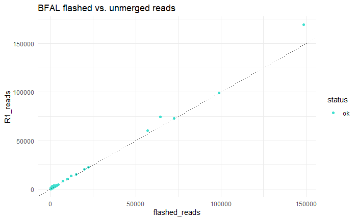

Make a list of the keepers and then change the primer concentration

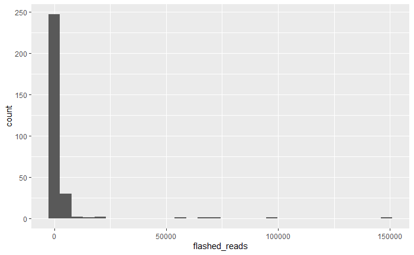

```r
test2_new_primer_multipliers <- keepers %>%
  mutate(multiplier = ifelse(flashed_reads >50000, 0.5, 1)) %>%
    mutate(multiplier = ifelse(flashed_reads >100000, 0.25, multiplier)) %>%
      mutate(multiplier = ifelse(flashed_reads <1000, 2, multiplier))
```

Now add on the working stock primer plate info to that

```r
# read in primer plate map
platemap <- readxl::read_xlsx("../IDTplateSpecs_BFALgtseq_20221012.xlsx")
```

```r
# select the relevant variables and make the sequence name match the data
platemap1 <- platemap %>%
  select(`Plate Name`, `Well Position`, `Sequence Name`) %>%
  rename(locus = `Sequence Name`)


tmp <- gsub("BFAL_", "", platemap1$locus)
tmp1 <- gsub("_R", "", tmp)
tmp2 <- gsub("_F", "", tmp1)

platemap1$locus <- tmp2

platemap2 <- platemap1 %>% # since the FWD and REV primers are combined in plates, I only need one plate/well entry per primer set
  filter(str_detect(`Plate Name`, "R"))
```

Assume we’re making 1000 ul of new primer pool

```r
tmp1 <- platemap2 %>%
  left_join(., test2_new_primer_multipliers, by = c("locus" = "Locus")) %>%
  mutate(previous_uM = 0.5) %>% # this would correspond to 2.5 ul per primer pair
  mutate(new_uM = previous_uM*multiplier) %>%
  mutate(cherrypick_ul = (new_uM*1000)/200) %>% # working conc is 200 uM and volume of primer pool is 1000
  mutate(cherrypick_ul = ifelse(is.na(cherrypick_ul), 0, cherrypick_ul)) # make zeros explicit

tmp1 %>%
  select(`Plate Name`, `Well Position`, locus, cherrypick_ul) %>%
  filter(cherrypick_ul >0) %>%
  summarise(sum(cherrypick_ul))
```

| sum(cherrypick_ul) |
| --- |
| 1001.25 |

```r
NA
```

That’s a little off… but the math should be right.

| Plate Name | Well Position | locus | cherrypick_ul |
| --- | --- | --- | --- |
| BFALgtseqPlate1R | A01 | scaffold_0_4330405 | 0.00 |
| BFALgtseqPlate1R | A02 | scaffold_5_697809 | 2.50 |
| BFALgtseqPlate1R | A03 | scaffold_9_4398937 | 5.00 |
| BFALgtseqPlate1R | A04 | scaffold_12_5002902 | 5.00 |
| BFALgtseqPlate1R | A05 | scaffold_15_5063205 | 2.50 |
| BFALgtseqPlate1R | A06 | scaffold_20_1133858 | 5.00 |
| BFALgtseqPlate1R | A07 | scaffold_24_1490422 | 5.00 |
| BFALgtseqPlate1R | A08 | scaffold_30_2857044 | 5.00 |
| BFALgtseqPlate1R | A09 | scaffold_34_2385714 | 2.50 |
| BFALgtseqPlate1R | A10 | scaffold_45_3079339 | 2.50 |

[output cut: 334 more lines]